# HGIS Pendleton Carbonates

Brett Longworth

2021-07-05

```r
library(tidyverse)
library(here)
library(openxlsx)
library(amstools)
library(hgis)
library(rbacon)

options(digits = 4)
options(scipen = 3)
```

Data analysis for Haiti core carbonates from Simon Pendleton. Data reduction is handled by the `analyse_carbonates.R` script in the `HybridGIS_work` project using the method and functions from the `hgis` package.

- Data are normalized using a CO2 tank standard in sample vials.
- Method blank correction uses carbonate C-1 in vials and assumes that all samples have the same blank, including standards.

Data reduction proceeds as follows:

1. Read raw file
2. Apply 13C correction to each run of a target
3. Determine per-target means, internal and external errors
4. Normalize targets using mean of standards and propagate errors
5. Apply a large blank correction using the mean of blanks and propagate errors

## Load results

```r
# Read raw and reduced data as produced by analyse_carbonates.R
data <- readRDS(here("data_analysed/carb_all.Rdata"))

# Read sample data
sample_data <- read_csv(here("data/carb_data.csv"))

# Select relevant raw data
raw <- map_dfr(data, 1) %>%
  filter(wheel %in% c("USAMS052621", "USAMS062921"),
         pos > 4)

# Select relevant reduced data, join with sample data
results <- map_dfr(data, 2) %>%
  filter(wheel %in% c("USAMS052621", "USAMS062921"),
         pos > 4) %>%
  left_join(sample_data, by = c("wheel", "pos")) %>%
  mutate(rec_num = ifelse(is.na(rec_num.y), rec_num.x, rec_num.y)) %>%
  select(-rec_num.x, -rec_num.y)

#write results to excel
#write.xlsx(results, here("data_analysed/haiti_carbonates.xlsx"))
```

### Currents and ratios vs time.

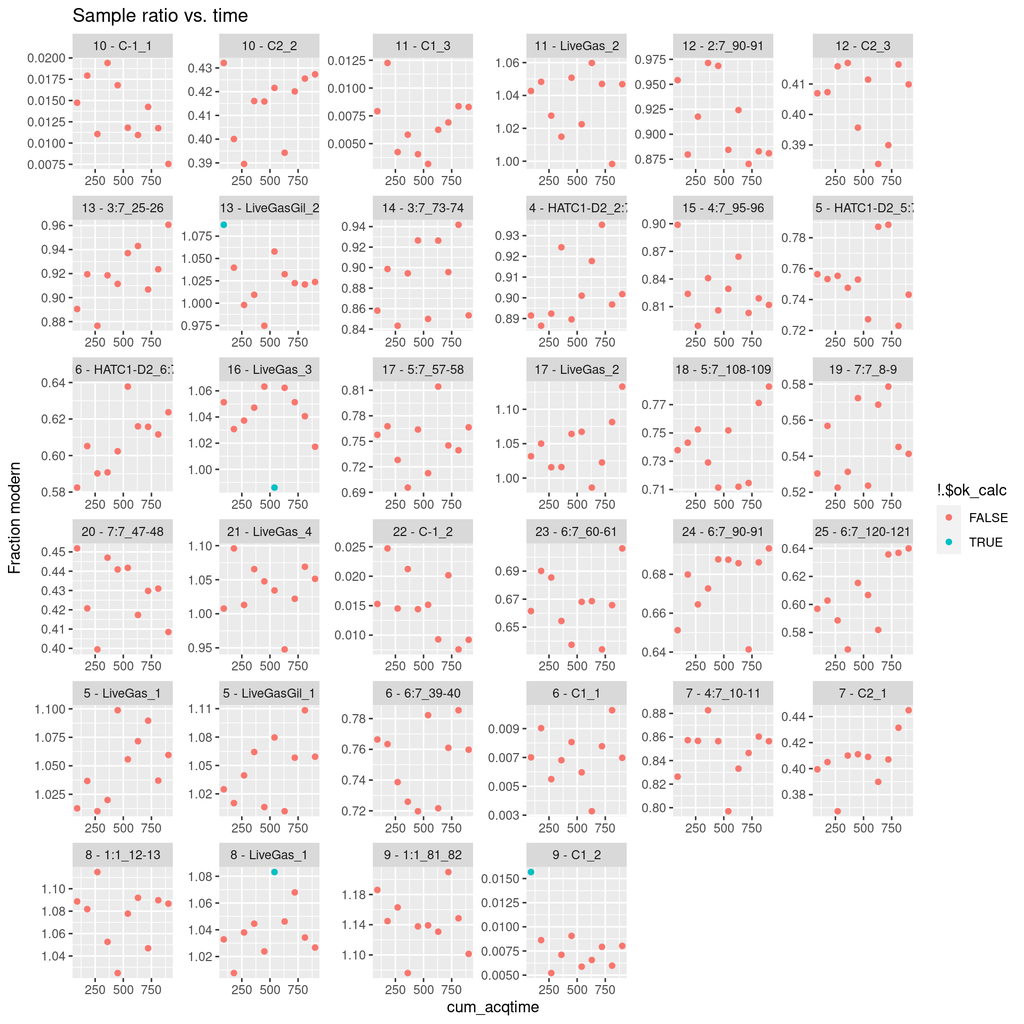

```r
raw %>%
  plot_hgis_time(norm_ratio, outlier = !.$ok_calc) +
  labs(title = "Sample ratio vs. time",
       y = "Fraction modern")
```

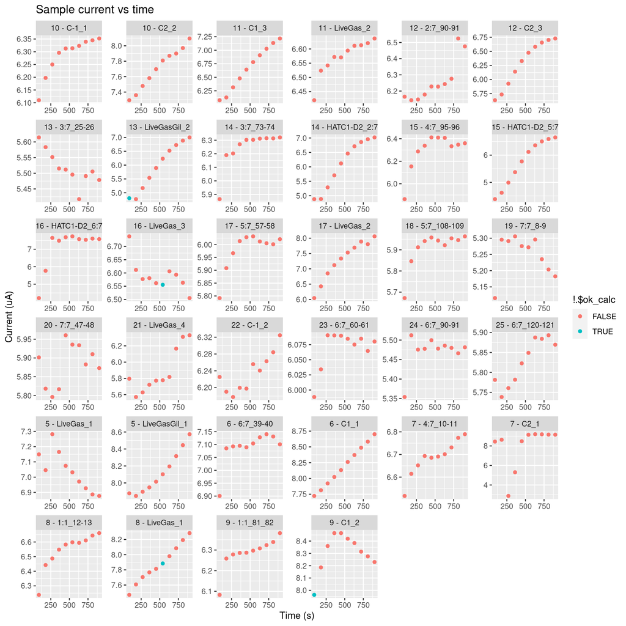

```r
raw %>%
  plot_hgis_time(he12C * 1E6, outlier = !.$ok_calc) +
  labs(title = "Sample current vs time",
       x = "Time (s)",
       y = "Current (uA)")
```

## Results

```r
results %>%
  mutate(he12C = he12C * 1E6) %>%
  select(Pos = pos, Name = sample_name, `Current (uA)` = he12C,
         `N runs` = n_runs, Fm = fm_corr, `Fm error` = sig_fm_corr) %>%
  arrange(Name) %>%
  knitr::kable()
```

| sample_type | Pos | Name | Current (uA) | N runs | Fm | Fm error |
| --- | --- | --- | --- | --- | --- | --- |
| U | 8 | 1:1_12-13 | 6.541 | 10 | 1.0745 | 0.0110 |
| U | 9 | 1:1_81_82 | 6.284 | 10 | 1.1435 | 0.0136 |
| U | 12 | 2:7_90-91 | 6.261 | 10 | 0.9104 | 0.0135 |
| U | 13 | 3:7_25-26 | 5.516 | 10 | 0.9158 | 0.0108 |
| U | 14 | 3:7_73-74 | 6.239 | 10 | 0.8855 | 0.0124 |
| U | 7 | 4:7_10-11 | 6.685 | 10 | 0.8434 | 0.0095 |
| U | 15 | 4:7_95-96 | 6.291 | 10 | 0.8245 | 0.0113 |
| U | 18 | 5:7_108-109 | 5.906 | 10 | 0.7354 | 0.0093 |
| U | 17 | 5:7_57-58 | 5.978 | 10 | 0.7440 | 0.0115 |
| U | 25 | 6:7_120-121 | 5.827 | 10 | 0.6004 | 0.0090 |
| U | 6 | 6:7_39-40 | 7.087 | 10 | 0.7474 | 0.0089 |
| U | 23 | 6:7_60-61 | 6.068 | 10 | 0.6611 | 0.0089 |
| U | 24 | 6:7_90-91 | 5.471 | 10 | 0.6690 | 0.0092 |
| U | 20 | 7:7_47-48 | 5.883 | 10 | 0.4198 | 0.0079 |
| U | 19 | 7:7_8-9 | 5.247 | 10 | 0.5395 | 0.0087 |
| B | 10 | C-1_1 | 6.284 | 10 | -0.0006 | 0.0072 |
| B | 22 | C-1_2 | 6.236 | 10 | 0.0010 | 0.0073 |
| B | 6 | C1_1 | 8.202 | 10 | 0.0027 | 0.0036 |
| B | 9 | C1_2 | 8.344 | 9 | 0.0028 | 0.0036 |
| B | 11 | C1_3 | 6.671 | 10 | 0.0023 | 0.0036 |
| U | 7 | C2_1 | 7.961 | 10 | 0.4059 | 0.0075 |
| U | 10 | C2_2 | 7.705 | 10 | 0.4127 | 0.0064 |
| U | 12 | C2_3 | 6.290 | 10 | 0.4038 | 0.0068 |
| U | 14 | HATC1-D2_2:7 | 6.089 | 10 | 0.9056 | 0.0105 |
| U | 15 | HATC1-D2_5:7 | 5.737 | 10 | 0.7543 | 0.0097 |
| U | 16 | HATC1-D2_6:7 | 7.082 | 10 | 0.6074 | 0.0080 |
| S | 8 | LiveGas_1 | 7.878 | 9 | 1.0386 | 0.0110 |
| S | 5 | LiveGas_1 | 7.041 | 10 | 1.0478 | 0.0114 |
| S | 17 | LiveGas_2 | 7.275 | 10 | 1.0498 | 0.0147 |
| S | 11 | LiveGas_2 | 6.570 | 10 | 1.0344 | 0.0107 |
| S | 16 | LiveGas_3 | 6.593 | 9 | 1.0432 | 0.0112 |
| S | 21 | LiveGas_4 | 5.889 | 10 | 1.0339 | 0.0142 |
| S | 5 | LiveGasGil_1 | 8.121 | 10 | 1.0481 | 0.0128 |
| S | 13 | LiveGasGil_2 | 6.082 | 9 | 1.0227 | 0.0119 |

## Agreement of replicates

Compare results for samples with more than one replicate.

```r
results %>%
  compare_replicates() %>%
  select(Name, `Mean current (uA)` = he12C_mean,
         `SD of current` = he12C_sd, `Mean Fm` = fm_corr_mean,
         `SD of Fm` = fm_corr_sd, `Mean sample error` = sig_fm_corr_mean) %>%
  knitr::kable()
```

| Name | Mean current (uA) | SD of current | Mean Fm | SD of Fm | Mean sample error |
| --- | --- | --- | --- | --- | --- |
| C2 | 7.319 | 0.8998 | 0.4075 | 0.0047 | 0.0069 |
| C1 | 7.147 | 1.0425 | 0.0016 | 0.0014 | 0.0050 |
| LiveGasGil | 6.931 | 0.8013 | 1.0398 | 0.0093 | 0.0123 |
| HATC1-D2 | 6.175 | 0.1216 | 0.9080 | 0.0034 | 0.0120 |
| HATC1-D2 | 5.821 | 0.1198 | 0.7449 | 0.0134 | 0.0095 |
| HATC1-D2 | 6.455 | 0.8879 | 0.6039 | 0.0049 | 0.0085 |

## Agreement with consensus

```r
cons <- results %>%
  filter(!is.na(fm_consensus)) %>%
  select(sample_name, fm_consensus, fm_corr, sig_fm_corr) %>%
  mutate(Fm_diff = fm_corr - fm_consensus,
         sigma = amstools::sigma(fm_corr, fm_consensus, sig_fm_corr)) %>%
  arrange(sample_name) %>%
  select(Name = sample_name,
         #`Mean current (uA)` = he12C_mean,
         #`SD of current` = he12C_sd,
         `Consensus Fm` = fm_consensus,
         Fm = fm_corr,
         `Fm error` = sig_fm_corr,
         `Difference` = Fm_diff,
         Sigma = sigma)

knitr::kable(cons)
```

| pos | sample_type | Name | Consensus Fm | Fm | Fm error | Difference | Sigma |
| --- | --- | --- | --- | --- | --- | --- | --- |
| 10 | B | C-1_1 | 0.0002 | -0.0006 | 0.0072 | -0.0008 | -0.1081 |
| 22 | B | C-1_2 | 0.0002 | 0.0010 | 0.0073 | 0.0008 | 0.1060 |
| 6 | B | C1_1 | 0.0002 | 0.0027 | 0.0036 | 0.0025 | 0.6967 |
| 9 | B | C1_2 | 0.0002 | 0.0028 | 0.0036 | 0.0026 | 0.7195 |
| 11 | B | C1_3 | 0.0002 | 0.0023 | 0.0036 | 0.0021 | 0.5937 |
| 7 | U | C2_1 | 0.4114 | 0.4059 | 0.0075 | -0.0055 | -0.7340 |
| 10 | U | C2_2 | 0.4114 | 0.4127 | 0.0064 | 0.0013 | 0.2076 |
| 12 | U | C2_3 | 0.4114 | 0.4038 | 0.0068 | -0.0076 | -1.1088 |
| 8 | S | LiveGas_1 | 1.0398 | 1.0386 | 0.0110 | -0.0012 | -0.1055 |
| 5 | S | LiveGas_1 | 1.0398 | 1.0478 | 0.0114 | 0.0080 | 0.7048 |
| 17 | S | LiveGas_2 | 1.0398 | 1.0498 | 0.0147 | 0.0100 | 0.6762 |
| 11 | S | LiveGas_2 | 1.0398 | 1.0344 | 0.0107 | -0.0054 | -0.5075 |
| 16 | S | LiveGas_3 | 1.0398 | 1.0432 | 0.0112 | 0.0034 | 0.2999 |
| 21 | S | LiveGas_4 | 1.0398 | 1.0339 | 0.0142 | -0.0059 | -0.4164 |
| 5 | S | LiveGasGil_1 | 1.0398 | 1.0481 | 0.0128 | 0.0083 | 0.6524 |
| 13 | S | LiveGasGil_2 | 1.0398 | 1.0227 | 0.0119 | -0.0171 | -1.4369 |

## Agreement with graphite

Agreement of Haiti core samples. Graphite samples were pretreated with HCl to leach 30% of the sample. HGIS samples not pretreated.

Load Simon’s data and compare

```r
names <- results %>%
  ungroup() %>%
  filter(wheel == "USAMS062921") %>%
  select(rec_num, sample_name)

graphite_results <- getRecOS(results$rec_num) %>%
  filter(!is.na(reported)) %>%
  select(rec_num, fm_corr = f_modern, sig_fm_corr = f_ext_error) %>%
  mutate(method = "graphite") %>%
  left_join(names, by = "rec_num")

combined_results <- results %>%
  filter(str_starts(sample_name, "HATC") | str_starts(sample_name, "\\d")) %>%
  mutate(method = "hgis") %>%
  select(wheel, sample_name, method, rec_num, fm_corr, sig_fm_corr) %>%
  bind_rows(graphite_results) %>%
  group_by(rec_num) %>%
  mutate(fm_mean = mean(fm_corr),
         fm_diff = fm_corr - fm_mean) %>%
  left_join(rename(names, Name = sample_name), by = "rec_num") %>%
  ungroup()

combined_results %>%
  select(sample_name, rec_num, method, fm_corr, sig_fm_corr) %>%
  arrange(rec_num) %>%
knitr::kable()
```

| sample_name | rec_num | method | fm_corr | sig_fm_corr |
| --- | --- | --- | --- | --- |
| 1:1_12-13 | 171987 | hgis | 1.0745 | 0.0110 |
| 1:1_12-13 | 171987 | graphite | 1.0629 | 0.0030 |
| 1:1_81_82 | 171988 | hgis | 1.1435 | 0.0136 |
| 1:1_81_82 | 171988 | graphite | 1.1362 | 0.0022 |
| HATC1-D2_2:7 | 171989 | hgis | 0.9056 | 0.0105 |
| 2:7_90-91 | 171989 | hgis | 0.9104 | 0.0135 |
| 2:7_90-91 | 171989 | graphite | 0.9217 | 0.0018 |
| 3:7_25-26 | 171990 | hgis | 0.9158 | 0.0108 |
| 3:7_25-26 | 171990 | graphite | 0.9140 | 0.0018 |
| 3:7_73-74 | 171991 | hgis | 0.8855 | 0.0124 |
| 3:7_73-74 | 171991 | graphite | 0.8778 | 0.0017 |
| 4:7_10-11 | 171992 | hgis | 0.8434 | 0.0095 |
| 4:7_10-11 | 171992 | graphite | 0.8502 | 0.0022 |
| 4:7_95-96 | 171993 | hgis | 0.8245 | 0.0113 |
| 4:7_95-96 | 171993 | graphite | 0.8296 | 0.0017 |
| 5:7_57-58 | 171994 | hgis | 0.7440 | 0.0115 |
| 5:7_57-58 | 171994 | graphite | 0.7555 | 0.0016 |
| HATC1-D2_5:7 | 171995 | hgis | 0.7543 | 0.0097 |
| 5:7_108-109 | 171995 | hgis | 0.7354 | 0.0093 |
| 5:7_108-109 | 171995 | graphite | 0.7543 | 0.0016 |
| 6:7_39-40 | 171996 | hgis | 0.7474 | 0.0089 |
| 6:7_39-40 | 171996 | graphite | 0.6946 | 0.0019 |
| 6:7_60-61 | 171997 | hgis | 0.6611 | 0.0089 |
| 6:7_60-61 | 171997 | graphite | 0.6631 | 0.0015 |
| 6:7_90-91 | 171998 | hgis | 0.6690 | 0.0092 |
| 6:7_90-91 | 171998 | graphite | 0.6682 | 0.0019 |
| HATC1-D2_6:7 | 171999 | hgis | 0.6074 | 0.0080 |
| 6:7_120-121 | 171999 | hgis | 0.6004 | 0.0090 |
| 6:7_120-121 | 171999 | graphite | 0.6062 | 0.0015 |
| 7:7_8-9 | 172000 | hgis | 0.5395 | 0.0087 |
| 7:7_8-9 | 172000 | graphite | 0.5402 | 0.0016 |
| 7:7_47-48 | 172001 | hgis | 0.4198 | 0.0079 |
| 7:7_47-48 | 172001 | graphite | 0.4309 | 0.0014 |

### Difference plot

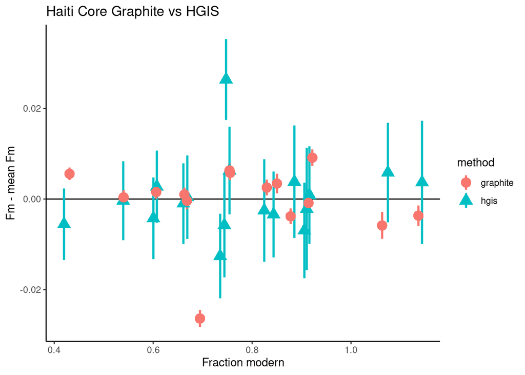

```r
combined_results %>%
  ggplot(aes(fm_corr, fm_diff, color = method, shape = method)) +
  geom_hline(yintercept = 0) +
  geom_pointrange(aes(ymin = fm_diff - sig_fm_corr,
                      ymax = fm_diff + sig_fm_corr),
                  size = 1) +#,
                  #position = position_dodge2(width = 0.02)) +
  #ylim(-0.02, 0.02) +
  labs(title = "Haiti Core Graphite vs HGIS",
       x = "Fraction modern",
       y = "Fm - mean Fm") + theme_classic()
```

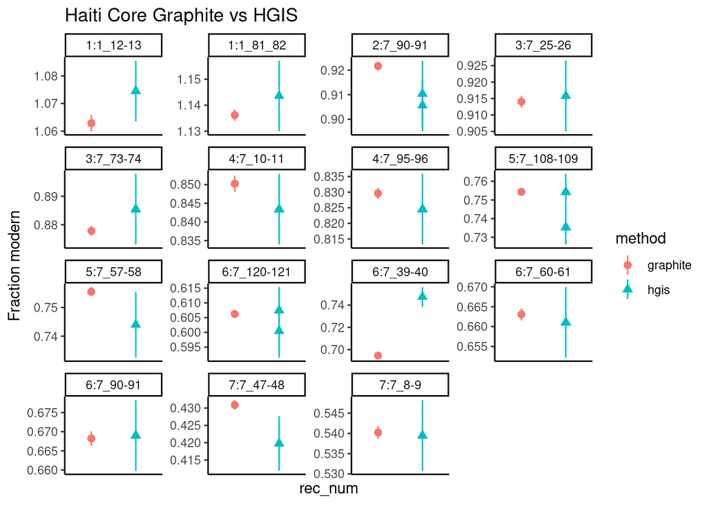

```r
combined_results %>%
  ggplot(aes(rec_num, fm_corr, color = method, shape = method)) +
  geom_pointrange(aes(ymin = fm_corr - sig_fm_corr,
                      ymax = fm_corr + sig_fm_corr),
                  size = .5,
                  position=position_dodge(width = .5)) +#,
                  #position = position_dodge2(width = 0.02)) +
  #ylim(-0.02, 0.02) +
  labs(title = "Haiti Core Graphite vs HGIS",
       y = "Fraction modern") +
  theme_classic() +
  theme(axis.text.x = element_blank(),
        axis.ticks.x = element_blank()) +
  facet_wrap("Name", scales = "free")
```

### Outlier

```r
combined_results %>%
  filter(abs(fm_diff) > 0.02) %>%
  select(sample_name, method, fm_corr, sig_fm_corr)
```

```
## # A tibble: 2 x 4
##   sample_name method   fm_corr sig_fm_corr
##   <chr>       <chr>      <dbl>       <dbl>
## 1 6:7_39-40   hgis       0.747     0.00893
## 2 6:7_39-40   graphite   0.695     0.00187
```

Sample 6:7_39-40 had an issue during prep. Vial was found to be at ~1 ATM during backfilling with helium. This means the vial had a leaky seal and would have entrained atmosphere (Fm ~0.9) during prep. This is the likely cause of a HGIS Fm 5.2% higher than graphite.

## Age vs depth

Add depth data and radiocarbon age

```r
depth <- read_csv(here("data/haiti_depth.csv"))

combined_results <- left_join(combined_results, depth, by = "rec_num") %>%
  mutate(rc_age = -8033 * log(fm_corr),
         sig_rc_age = rc_age - -8033 * log(fm_corr + sig_fm_corr))
```

Fm depth plot

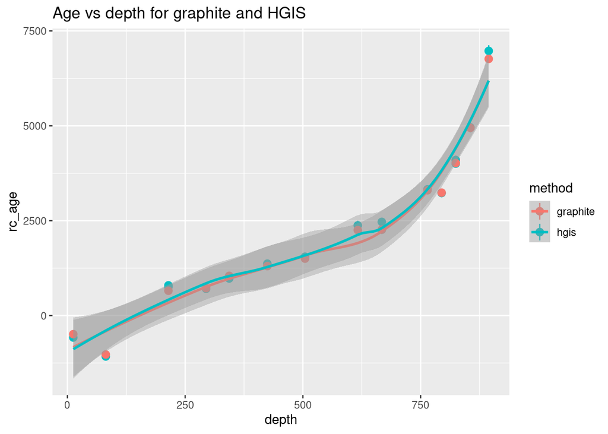

```r
combined_results %>%
  filter(sample_name != "6:7_39-40") %>%
ggplot(aes(depth, rc_age, color = method)) +
  geom_pointrange(aes(ymin = rc_age - sig_rc_age,
                      ymax = rc_age + sig_rc_age),
                  size = 0.5) +
  geom_smooth() +
  ggtitle("Age vs depth for graphite and HGIS")
```

Mmmm…. Bacon

```r
# Bacon data format
# graphite
combined_results %>%
  filter(method == "graphite",
         rc_age > 0) %>%
  select(labID = Name, age = rc_age, error = sig_rc_age, depth) %>%
  write_csv(here("Bacon_runs/haiti_graphite/haiti_graphite.csv"))

# hgis
combined_results %>%
  filter(method == "hgis",
         sample_name != "6:7_39-40",
         !str_starts(sample_name, "HATC"),
         rc_age > 0) %>%
  select(labID = Name, age = rc_age, error = sig_rc_age, depth) %>%
  write_csv(here("Bacon_runs/haiti_hgis/haiti_hgis.csv"))
```

Trying Bchron here instead. Use is a bit friendlier in Rmarkdown.

```r
library(Bchron)

cal_sub <- combined_results %>%
  filter(rc_age > 0) %>%
  mutate(id = paste(sample_name, "-", method)) %>%
  select(id, depth, rc_age, sig_rc_age)

cal_dates <- with(cal_sub,
  BchronCalibrate(rc_age, sig_rc_age, positions = depth, ids = id))
```

```
## Calibrating curve not provided. Using: intcal20
```

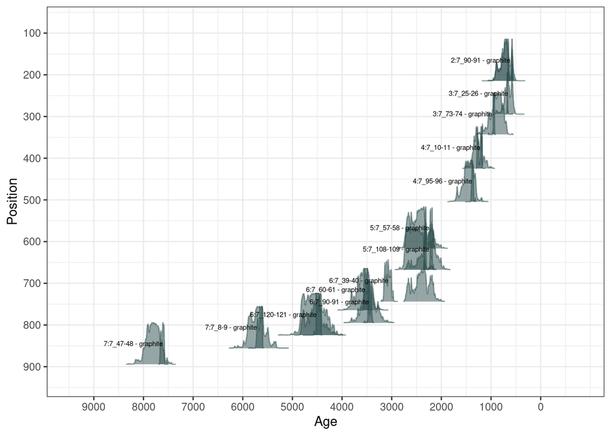

```r
plot(cal_dates)
```